# GRN-scPerturbSim: simulate single-cell perturbation data

# 1 Overview

GRN-scPerturbSim generates single-cell perturbation count data under a synthetic gene regulatory network (GRN). The `simulate_grn_guided_expression()` function uses a supplied count matrix and cell-group labels as a reference for the simulated data.

This tutorial first creates a small artificial dataset and uses it as the reference input. When applying the simulator, replace this illustrative input with your experimental single-cell perturbation data.

# 2 Create illustrative reference input

The reference input contains 10 genes and three groups: wild-type cells and cells in which `Gene1` or `Gene2` is perturbed. The Poisson counts below serve only as a compact, executable illustration of the required input structure.

```r
library(CausalGRN)

set.seed(seed = 42)

n_genes <- 10
n_cells_per_group <- 50
genes <- paste0("Gene", seq_len(n_genes))
perturbed_genes <- c("Gene1", "Gene2")
groups <- c("WT", perturbed_genes)
n_groups <- length(groups)

count_real_data <- matrix(
  data = rpois(
    n = n_groups * n_cells_per_group * n_genes,
    lambda = 10
  ),
  nrow = n_groups * n_cells_per_group,
  ncol = n_genes
)
colnames(count_real_data) <- genes

group_real_data <- rep(
  x = groups,
  each = n_cells_per_group
)
cell_names <- paste0("Cell", seq_along(group_real_data))
rownames(count_real_data) <- cell_names
names(group_real_data) <- cell_names
```

`count_real_data` is a cell-by-gene count matrix. `group_real_data` is a named character vector with one label per matrix row: `"WT"` denotes wild-type cells, and a gene name denotes cells in which that gene is perturbed. The vector names must be identical to the count-matrix row names.

# 3 Run GRN-scPerturbSim

```r
sim_data <- simulate_grn_guided_expression(
  d = 2,
  count = count_real_data,
  group = group_real_data
)
```

The required arguments are:

- `d = 2`: the expected total degree per gene in the simulated DAG, counting both parents and children.
- `count = count_real_data`: the reference cell-by-gene count matrix.
- `group = group_real_data`: the reference cell-group labels aligned with the rows of `count_real_data`.

See `?simulate_grn_guided_expression` for optional simulation controls.

# 4 Inspect the simulated dataset

The returned list contains:

- `sim_data$dag`: the ground-truth simulated DAG.
- `sim_data$coef`: the ground-truth regulatory coefficients.
- `sim_data$count`: the simulated cell-by-gene count matrix.
- `sim_data$group`: the group label for each row of `sim_data$count`.

The 10-gene DAG is small enough to inspect directly:

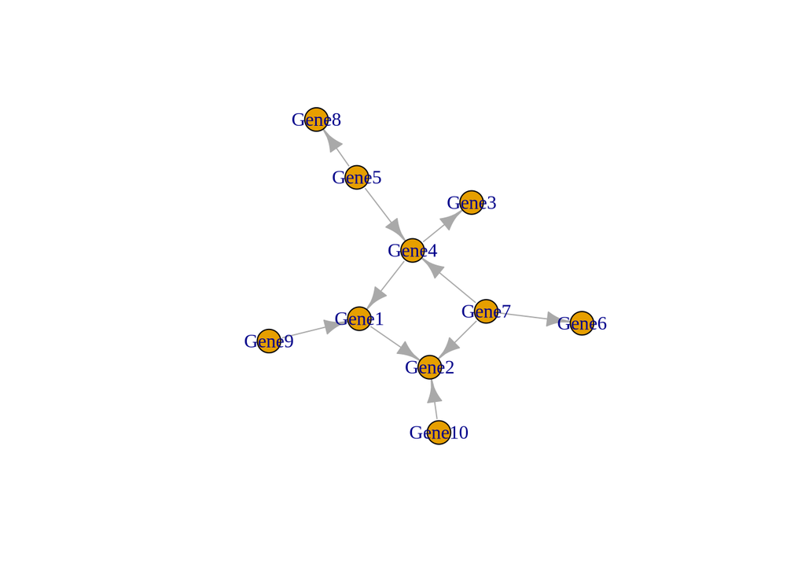

```r
plot(x = sim_data$dag)
```

The dimensions of the simulated count matrix and the number of cells in each group are:

```r
dim(x = sim_data$count)
```

```
#> [1] 150  10
```

```r
table(group = sim_data$group)
```

```
#> group
#> Gene1 Gene2    WT
#>    50    50    50
```